# Algoritmos supervisionados para classificação

### Realizado por: Patrícia Ferreira da Silva

### Tutor: Felipe Fink Grael

### 1 Explique a motivação de uso da base escolhida

#### Prevendo a rotatividade de clientes do banco( se o cliente saiu ou não do banco )

O objetivo deste projeto é entender por que os clientes estão saindo do Banco e construir um modelo preditivo para examinar quem provavelmente sairá no futuro.

# EDA

```python
import pandas as pd
import matplotlib.pyplot as plt
import numpy as np
import pandas as pd
import seaborn as sns
from IPython.core.interactiveshell import InteractiveShell
InteractiveShell.ast_node_interactivity = "all"
from sklearn.svm import SVC
from sklearn.preprocessing import StandardScaler
from sklearn.model_selection import train_test_split
from sklearn.linear_model import LogisticRegression
from imblearn.pipeline import Pipeline
from imblearn.over_sampling import SMOTE
from imblearn.under_sampling import RandomUnderSampler
```

```python
df = pd.read_csv("churn2.csv", sep=',')
df.head(5)
```

|  | RowNumber | CustomerId | Surname | CreditScore | Geography | Gender | Age | Tenure | Balance | NumOfProducts | HasCrCard | IsActiveMember | EstimatedSalary | Exited |
| --- | --- | --- | --- | --- | --- | --- | --- | --- | --- | --- | --- | --- | --- | --- |
| 0 | 1 | 15634602 | Hargrave | 619 | France | Female | 42 | 2 | 0.00 | 1 | 1 | 1 | 101348.88 | 1 |
| 1 | 2 | 15647311 | Hill | 608 | Spain | Female | 41 | 1 | 83807.86 | 1 | 0 | 1 | 112542.58 | 0 |
| 2 | 3 | 15619304 | Onio | 502 | France | Female | 42 | 8 | 159660.80 | 3 | 1 | 0 | 113931.57 | 1 |
| 3 | 4 | 15701354 | Boni | 699 | France | Female | 39 | 1 | 0.00 | 2 | 0 | 0 | 93826.63 | 0 |
| 4 | 5 | 15737888 | Mitchell | 850 | Spain | Female | 43 | 2 | 125510.82 | 1 | 1 | 1 | 79084.10 | 0 |

### 2 - Descreva as variáveis presentes na base. Quais são as variáveis? Quais são os tipos de variáveis (discreta, categórica, contínua)? Quais são as médias e desvios padrões?

```python
df.info()
df.describe()
```

```
<class 'pandas.core.frame.DataFrame'>
RangeIndex: 10000 entries, 0 to 9999
Data columns (total 14 columns):
 #   Column           Non-Null Count  Dtype
---  ------           --------------  -----
 0   RowNumber        10000 non-null  int64
 1   CustomerId       10000 non-null  int64
 2   Surname          10000 non-null  object
 3   CreditScore      10000 non-null  int64
 4   Geography        10000 non-null  object
 5   Gender           10000 non-null  object
 6   Age              10000 non-null  int64
 7   Tenure           10000 non-null  int64
 8   Balance          10000 non-null  float64
 9   NumOfProducts    10000 non-null  int64
 10  HasCrCard        10000 non-null  int64
 11  IsActiveMember   10000 non-null  int64
 12  EstimatedSalary  10000 non-null  float64
 13  Exited           10000 non-null  int64
dtypes: float64(2), int64(9), object(3)
memory usage: 1.1+ MB
```

|  | RowNumber | CustomerId | CreditScore | Age | Tenure | Balance | NumOfProducts | HasCrCard | IsActiveMember | EstimatedSalary | Exited |
| --- | --- | --- | --- | --- | --- | --- | --- | --- | --- | --- | --- |
| count | 10000.00000 | 1.000000e+04 | 10000.000000 | 10000.000000 | 10000.000000 | 10000.000000 | 10000.000000 | 10000.00000 | 10000.000000 | 10000.000000 | 10000.000000 |
| mean | 5000.50000 | 1.569094e+07 | 650.528800 | 38.921800 | 5.012800 | 76485.889288 | 1.530200 | 0.70550 | 0.515100 | 100090.239881 | 0.203700 |
| std | 2886.89568 | 7.193619e+04 | 96.653299 | 10.487806 | 2.892174 | 62397.405202 | 0.581654 | 0.45584 | 0.499797 | 57510.492818 | 0.402769 |
| min | 1.00000 | 1.556570e+07 | 350.000000 | 18.000000 | 0.000000 | 0.000000 | 1.000000 | 0.00000 | 0.000000 | 11.580000 | 0.000000 |
| 25% | 2500.75000 | 1.562853e+07 | 584.000000 | 32.000000 | 3.000000 | 0.000000 | 1.000000 | 0.00000 | 0.000000 | 51002.110000 | 0.000000 |
| 50% | 5000.50000 | 1.569074e+07 | 652.000000 | 37.000000 | 5.000000 | 97198.540000 | 1.000000 | 1.00000 | 1.000000 | 100193.915000 | 0.000000 |
| 75% | 7500.25000 | 1.575323e+07 | 718.000000 | 44.000000 | 7.000000 | 127644.240000 | 2.000000 | 1.00000 | 1.000000 | 149388.247500 | 0.000000 |
| max | 10000.00000 | 1.581569e+07 | 850.000000 | 92.000000 | 10.000000 | 250898.090000 | 4.000000 | 1.00000 | 1.000000 | 199992.480000 | 1.000000 |

## Variáveis que irei utilizar no modelo

- Credit Score :Pontuação de crédito ---------------Variável Quantitativa continua
- Geography :Geografia--------------------------------Variável categorica
- Gender :Gênero ----------------------------------------Variável categorica ordinal
- Age :Idade------------------------------------------------Variável Quantitativa continua continua
- Tenure :Posse--------------------------------------------Variável quantitativa discreta
- Balance :Equilíbrio--------------------------------------Variável Quantitativa continua
- Number Of Products:Número de produtos--------Variável discreta
- Is Active Member :É membro ativo-------------------Rótulo
- Has Credit Card :tem cartão de crédito--------------variável Quantitativa discreta
- Estimated Salary :Salário Estimado------------------variável quantitativa continua
- Exited :Saiu--------------------------------------------------Rótulo

```python
df = df.drop(df.columns[0:3], axis=1)
#FAZENDO DROP NAS 3 PRIMEIRAS COLUNAS
```

```python
# RENOMEANDO A COLUNA HasCrCard
mapping = {'HasCrCard':'HasCreditCard'
          }
df=df.rename(columns=mapping)
df.head()
```

|  | CreditScore | Geography | Gender | Age | Tenure | Balance | NumOfProducts | HasCreditCard | IsActiveMember | EstimatedSalary | Exited |
| --- | --- | --- | --- | --- | --- | --- | --- | --- | --- | --- | --- |
| 0 | 619 | France | Female | 42 | 2 | 0.00 | 1 | 1 | 1 | 101348.88 | 1 |
| 1 | 608 | Spain | Female | 41 | 1 | 83807.86 | 1 | 0 | 1 | 112542.58 | 0 |
| 2 | 502 | France | Female | 42 | 8 | 159660.80 | 3 | 1 | 0 | 113931.57 | 1 |
| 3 | 699 | France | Female | 39 | 1 | 0.00 | 2 | 0 | 0 | 93826.63 | 0 |
| 4 | 850 | Spain | Female | 43 | 2 | 125510.82 | 1 | 1 | 1 | 79084.10 | 0 |

```python
df.shape
```

```
(10000, 11)
```

```python
df.duplicated().sum()
```

```
0
```

```python
df.isnull().sum()
```

```
CreditScore        0
Geography          0
Gender             0
Age                0
Tenure             0
Balance            0
NumOfProducts      0
HasCreditCard      0
IsActiveMember     0
EstimatedSalary    0
Exited             0
dtype: int64
```

```
array([[<Axes: title={'center': 'CreditScore'}>,
        <Axes: title={'center': 'Age'}>,
        <Axes: title={'center': 'Tenure'}>],
       [<Axes: title={'center': 'Balance'}>,
        <Axes: title={'center': 'NumOfProducts'}>,
        <Axes: title={'center': 'HasCreditCard'}>],
       [<Axes: title={'center': 'IsActiveMember'}>,
        <Axes: title={'center': 'EstimatedSalary'}>,
        <Axes: title={'center': 'Exited'}>]], dtype=object)
```

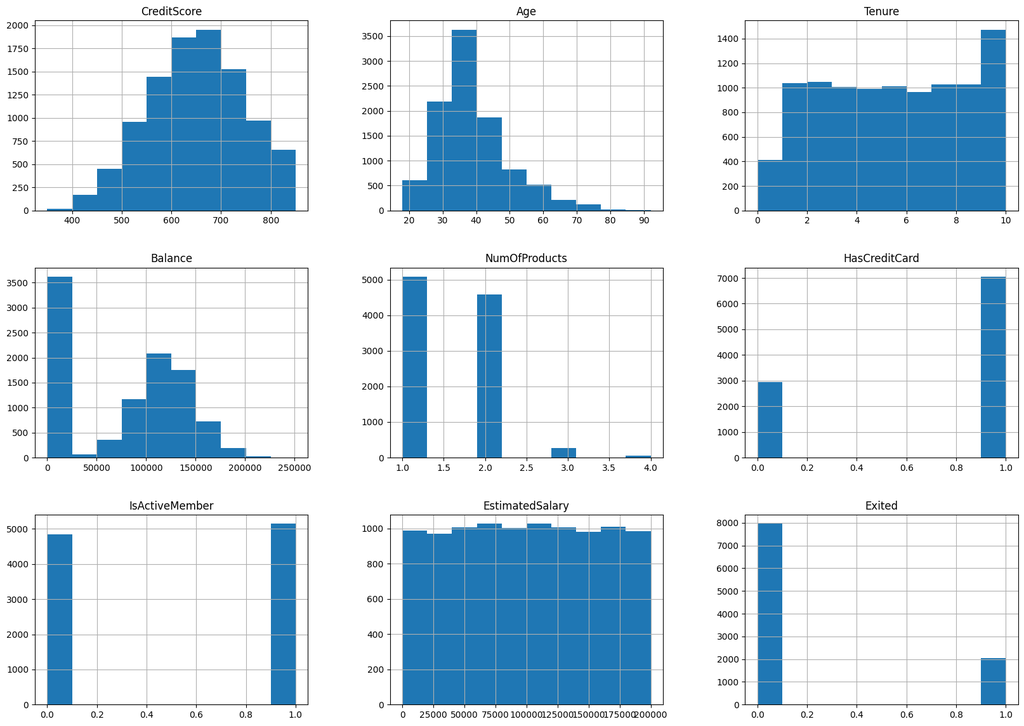

```python
df.hist(figsize=(20,14))
```

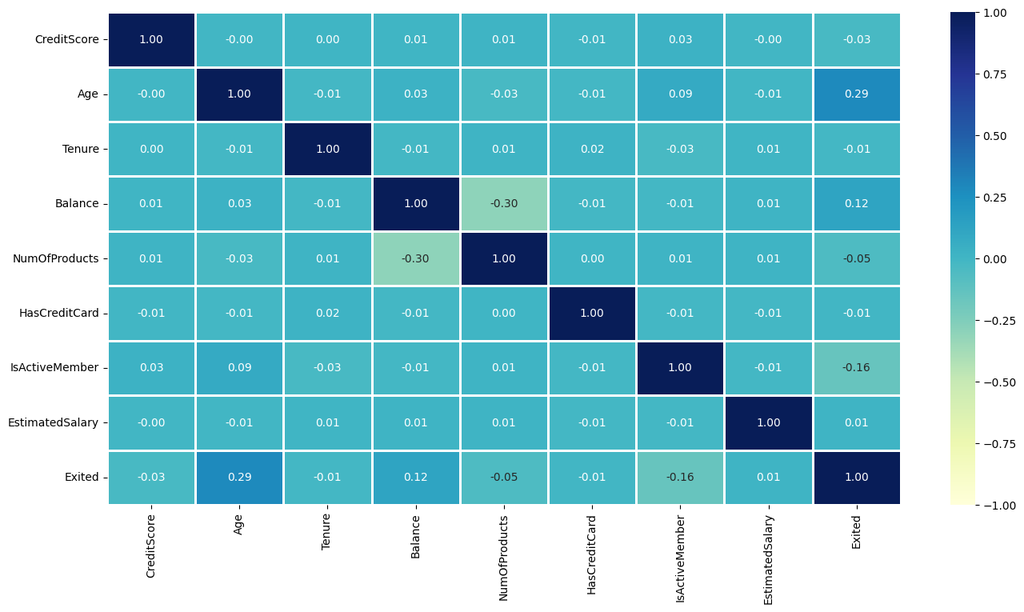

```python
plt.rcParams['figure.figsize'] = (16,8)
sns.heatmap(df.corr(), cmap='YlGnBu',
            linewidths = 2, vmin=-1, vmax=1, fmt='.2f', annot=True)
```

#### 3- Em relação à base escolhida:

- A- Você irá comparar alguns modelos para prever as classes. Descreva como a validação cruzada pode ser usada para comparar modelos de maneira justa. Descreva o procedimento e como a métrica final é calculada.

#### Resposta:

- validação cruzada dividi os dados em várias partições e treina vários algoritmos nessas partições.Desta forma melhora a robustez do modelo mantendo os dados do processo de treinamento.Além de melhorar o desempenho em observações não vistas,em ambientes com poucos dados,pode ser mais eficiente para treinar modelos.

##### Descreva o procedimento e como a métrica final é calculada

- k-fold consiste em dividir o conjunto total de dados em k subconjuntos mutuamente exclusivos do mesmo tamanho e, a partir daí, um subconjunto é utilizado para teste e os k-1 restantes são utilizados para estimação dos parâmetros, fazendo-se o cálculo da acurácia do modelo, ao final das k iterações calcula-se a acurácia sobre os erros encontrados.
- B - A base se encontra com as classes balanceadas? Cite uma maneira de resolver no caso das classes estarem desbalanceadas.

##### Resposta:

A base escolhida encontra se desbalanceada utilizei o metódo Random under-sampling para deixar balanceada.

##### No caso de bases desbalanceadas pode usar :

```python
#df['IsActiveMember'].value_counts()

#df['Gender'].value_counts()
#df['CreditScore'].value_counts()
#df['Geography'].value_counts()
#df['Age'].value_counts()
#df['Tenure'].value_counts()
#df['Balance'].value_counts()
#df['NumOfProducts'].value_counts()
#df['HasCreditCard'].value_counts()
#df['EstimatedSalary'].value_counts()
df['Exited'].value_counts()
```

```
0    7963
1    2037
Name: Exited, dtype: int64
```

```python
count_class_0, count_class_1 = df.Exited.value_counts()
df_class_0 = df[df['Exited'] == 0]
df_class_1 = df[df['Exited'] == 1]
```

```
Random under-sampling:
0    2037
1    2037
Name: Exited, dtype: int64
```

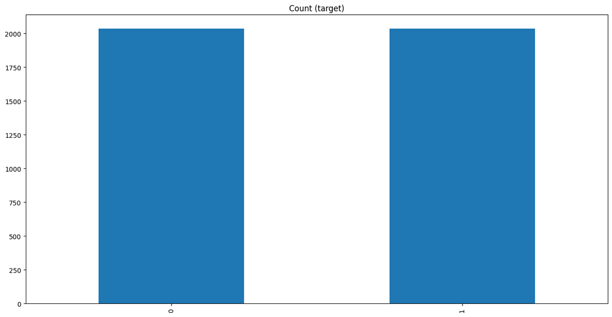

```python
df_class_0_under = df_class_0.sample(count_class_1)
df_test_under = pd.concat([df_class_0_under, df_class_1], axis=0)

print('Random under-sampling:')
print(df_test_under.Exited.value_counts())

df_test_under.Exited.value_counts().plot(kind='bar', title='Count (target)');
```

### 4 - Qual a diferença entre uma regressão linear e a regressão logística?

- Regressão linear é utilizada em problemas em que queremos identificar um modelo que representa a relação entre duas variáveis, sendo que uma altera o valor da outra de maneira linear.
- Regressão Logística é utilizada quando a variável dependente for do tipo categórica e os dados puderem ser agrupados em duas classes, deve ser usada em problemas de classificação binários.

### 5- Com a base escolhida:

- A . Descreva as etapas necessárias para criar um modelo de classificação eficiente
- 1. Entendimento do negócio;
- 1. entendimento dos dados;
- 1. modelagem dos dados;
- 1. avaliação dos resultados;
- 1. deployment (produção).
- Para gerar um modelo de classificação eficiente teremos que focar um pouco mais no processamento de dados.No que seria, transformar dados brutos em formatos úteis e eficientes, começando pela limpeza dos dados pois pode haver dados faltantes, remoção de valores incomuns entre outros, após isso passamos para a etapa de transformação dos dados, onde é feita a normalização, seleção de atributos caso a base de dados estiver muito grande podemos reduzir esse volume, assim podemos reduzir os custos e aumentar a eficiência.

# C- SVM Support Vector Machine

```python
X = df_test_under.iloc[:, :-1]
X = pd.get_dummies(X)
#X.head()
y = df_test_under.Exited #variavel target
from sklearn.preprocessing import LabelEncoder
```

```python
gender_encoder = LabelEncoder()
y = gender_encoder.fit_transform(y)
y
```

```
array([0, 0, 0, ..., 1, 1, 1], dtype=int64)
```

```python
# Scale the data to be between -1 and 1
from sklearn.preprocessing import StandardScaler
scaler = StandardScaler()
scaler.fit(X)
X = scaler.transform(X)
```

```
StandardScaler()
```

```python
#X_train, X_test, y_train, y_test = train_test_split(x, y, train_size=0.8, random_state=23032026, stratify=y)
X_train, X_test, y_train, y_test = train_test_split(X, y, test_size=0.3, random_state=0)
```

```python
pred
```

[output not shown]

```python
svc=SVC() #Default hyperparameters
svc.fit(X_train,y_train)
y_pred=svc.predict(X_test)
```

```
SVC()
```

```python
#print("Train Accuracy score : ",round(svc.score(x_train,y_train)*100,2),"%")
#print('Model accuracy with rbf kernel : {0:0.3f}'. format(accuracy_score(y_test, y_pred)))
```

```
 Train Accuracy score :  80.43 %
Test Accuracy Score:
0.776778413736713
----------------------
Classification Report
              precision    recall  f1-score   support

           0       0.77      0.80      0.78       619
           1       0.79      0.75      0.77       604

    accuracy                           0.78      1223
   macro avg       0.78      0.78      0.78      1223
weighted avg       0.78      0.78      0.78      1223

----------------------
```

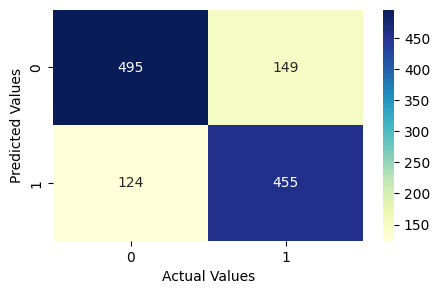

```python
rbf_svc=SVC(kernel='rbf').fit(X_train,y_train)
y_pred = rbf_svc.predict(X_test)
print(" Train Accuracy score : ",round(svc.score(X_train,y_train)*100,2),"%")

print('Test Accuracy Score:')
print(metrics.accuracy_score(y_test,y_pred))

print("----------------------")
print("Classification Report")
print(classification_report(y_test,y_pred))

print("----------------------")
con = confusion_matrix(y_pred,y_test)
plt.figure(figsize=(5,3))
sns.heatmap(con, annot=True,cmap="YlGnBu",fmt='g')
plt.xlabel('Actual Values')
plt.ylabel('Predicted Values')
```

```python
y_train
```

```
array([1, 0, 1, ..., 0, 1, 1], dtype=int64)
```

# B - Árvores de Classificação

```python
#função auxiliar para imprimir relatório de classificação
from sklearn.metrics import accuracy_score, confusion_matrix, classification_report

def print_score(clf, X_train, y_train, X_test, y_test, train=True):
    if train:
        pred = clf.predict(X_train)
        clf_report = pd.DataFrame(classification_report(y_train, pred, output_dict=True))
        print("Train Result:\n================================================")
        print(f"Accuracy Score: {accuracy_score(y_train, pred) * 100:.2f}%")
        print("_______________________________________________")
        print(f"CLASSIFICATION REPORT:\n{clf_report}")
        print("_______________________________________________")
        print(f"Confusion Matrix: \n {confusion_matrix(y_train, pred)}\n")

    elif train==False:
        pred = clf.predict(X_test)
        clf_report = pd.DataFrame(classification_report(y_test, pred, output_dict=True))
        print("Test Result:\n================================================")
        print(f"Accuracy Score: {accuracy_score(y_test, pred) * 100:.2f}%")
        print("_______________________________________________")
        print(f"CLASSIFICATION REPORT:\n{clf_report}")
        print("_______________________________________________")
        print(f"Confusion Matrix: \n {confusion_matrix(y_test, pred)}\n")
```

```python
from sklearn.tree import DecisionTreeClassifier, plot_tree
```

```python
x = df_test_under.drop(['Exited'],axis=1)
x = pd.get_dummies(x)

y= df_test_under.Exited
x
```

|  | CreditScore | Age | Tenure | Balance | NumOfProducts | HasCreditCard | IsActiveMember | EstimatedSalary | Geography_France | Geography_Germany | Geography_Spain | Gender_Female | Gender_Male |
| --- | --- | --- | --- | --- | --- | --- | --- | --- | --- | --- | --- | --- | --- |
| 6940 | 575 | 46 | 1 | 0.00 | 2 | 1 | 1 | 65998.26 | 1 | 0 | 0 | 0 | 1 |
| 6796 | 651 | 25 | 8 | 0.00 | 2 | 1 | 1 | 126761.20 | 1 | 0 | 0 | 1 | 0 |
| 222 | 567 | 42 | 2 | 0.00 | 2 | 1 | 1 | 167984.61 | 1 | 0 | 0 | 0 | 1 |
| 3065 | 503 | 42 | 8 | 104430.08 | 1 | 1 | 1 | 147557.71 | 1 | 0 | 0 | 0 | 1 |
| 3644 | 593 | 32 | 3 | 0.00 | 2 | 1 | 1 | 151978.36 | 1 | 0 | 0 | 1 | 0 |
| ... | ... | ... | ... | ... | ... | ... | ... | ... | ... | ... | ... | ... | ... |
| 9981 | 498 | 42 | 3 | 152039.70 | 1 | 1 | 1 | 53445.17 | 0 | 1 | 0 | 0 | 1 |
| 9982 | 655 | 46 | 7 | 137145.12 | 1 | 1 | 0 | 115146.40 | 0 | 1 | 0 | 1 | 0 |
| 9991 | 597 | 53 | 4 | 88381.21 | 1 | 1 | 0 | 69384.71 | 1 | 0 | 0 | 1 | 0 |
| 9997 | 709 | 36 | 7 | 0.00 | 1 | 0 | 1 | 42085.58 | 1 | 0 | 0 | 1 | 0 |
| 9998 | 772 | 42 | 3 | 75075.31 | 2 | 1 | 0 | 92888.52 | 0 | 1 | 0 | 0 | 1 |

4074 rows × 13 columns

```python
#X_train, X_test, y_train, y_test = train_test_split(x, y, test_size = 0.3, random_state = 42)
X_train, X_test, y_train, y_test = train_test_split(x, y, train_size=0.8, random_state=13022023, stratify=y)
```

```python
sc = StandardScaler()
X_train = sc.fit_transform(X_train)
X_test = sc.transform(X_test)
```

```python
model_1 = DecisionTreeClassifier()
model_1.fit(X_train, y_train)
predict_1 = model_1.predict(X_test)
predict_1
```

```
DecisionTreeClassifier()
```

```
array([1, 0, 1, 0, 1, 0, 0, 0, 1, 1, 0, 0, 0, 0, 0, 0, 0, 1, 0, 1, 1, 1,
       1, 1, 0, 1, 0, 0, 1, 0, 0, 1, 1, 0, 0, 1, 0, 0, 0, 1, 0, 1, 1, 0,
       1, 0, 1, 1, 0, 1, 1, 1, 1, 1, 1, 0, 0, 1, 1, 0, 0, 1, 1, 0, 1, 0,
       1, 0, 1, 0, 0, 0, 1, 0, 1, 1, 1, 0, 1, 1, 0, 1, 0, 0, 0, 0, 1, 1,
       1, 0, 1, 0, 0, 1, 0, 0, 0, 1, 0, 1, 0, 1, 0, 1, 0, 0, 1, 1, 1, 0,
       0, 0, 0, 1, 1, 0, 0, 1, 1, 1, 1, 0, 0, 1, 1, 1, 0, 1, 0, 1, 1, 0,
       0, 1, 0, 0, 0, 1, 0, 0, 1, 0, 0, 0, 0, 1, 1, 1, 1, 0, 1, 0, 0, 0,
       1, 0, 1, 1, 1, 0, 1, 0, 0, 1, 0, 0, 0, 0, 0, 1, 1, 1, 0, 1, 1, 0,
       1, 1, 1, 0, 1, 1, 1, 0, 1, 0, 0, 1, 0, 0, 1, 1, 1, 1, 0, 0, 0, 0,
       0, 0, 0, 0, 1, 1, 1, 1, 1, 0, 0, 0, 1, 0, 1, 0, 0, 0, 1, 0, 0, 1,
       0, 1, 1, 0, 1, 1, 1, 1, 0, 0, 1, 0, 1, 0, 1, 1, 0, 0, 0, 1, 0, 1,
       0, 0, 0, 0, 1, 1, 1, 1, 0, 0, 1, 0, 1, 0, 1, 1, 1, 0, 0, 1, 1, 0,
       1, 1, 1, 0, 1, 0, 1, 1, 0, 1, 0, 1, 1, 0, 1, 0, 1, 0, 1, 0, 0, 0,
       1, 0, 0, 0, 1, 1, 1, 1, 0, 0, 0, 1, 1, 1, 0, 0, 0, 0, 0, 1, 0, 0,
       1, 0, 1, 1, 1, 1, 0, 1, 1, 0, 0, 0, 0, 1, 0, 0, 0, 1, 0, 1, 0, 1,
```

[output cut: 23 more lines]

```python
#y_test
```

```python
model_1 = DecisionTreeClassifier()
model_1.fit(X_train, y_train)
print(classification_report(y_test,predict_1))
print("Train Accuracy score : ",round(lr.score(X_train,y_train)*100,2),"%")
#print(metrics.accuracy_score(y_test,predict_1))

print()
print('*****************************************************')
print('------------------------------------------')
print_score(model_1, X_train, y_train, X_test, y_test, train=False)
```

```
DecisionTreeClassifier()
```

```
              precision    recall  f1-score   support

           0       0.69      0.72      0.70       407
           1       0.71      0.67      0.69       408

    accuracy                           0.70       815
   macro avg       0.70      0.70      0.70       815
weighted avg       0.70      0.70      0.70       815

Train Accuracy score :  69.71 %

------------------------------------------
Test Result:
================================================
Accuracy Score: 70.55%
_______________________________________________
CLASSIFICATION REPORT:
                    0           1  accuracy   macro avg  weighted avg
precision    0.697400    0.714286  0.705521    0.705843      0.705853
recall       0.724816    0.686275  0.705521    0.705545      0.705521
f1-score     0.710843    0.700000  0.705521    0.705422      0.705415
support    407.000000  408.000000  0.705521  815.000000    815.000000
_______________________________________________
Confusion Matrix:
 [[295 112]
 [128 280]]
```

# Regressão Logística

```python
from sklearn.linear_model import LogisticRegression
from sklearn.model_selection import GridSearchCV, StratifiedKFold
```

```python
df_test_under
```

|  | CreditScore | Geography | Gender | Age | Tenure | Balance | NumOfProducts | HasCreditCard | IsActiveMember | EstimatedSalary | Exited |
| --- | --- | --- | --- | --- | --- | --- | --- | --- | --- | --- | --- |
| 6940 | 575 | France | Male | 46 | 1 | 0.00 | 2 | 1 | 1 | 65998.26 | 0 |
| 6796 | 651 | France | Female | 25 | 8 | 0.00 | 2 | 1 | 1 | 126761.20 | 0 |
| 222 | 567 | France | Male | 42 | 2 | 0.00 | 2 | 1 | 1 | 167984.61 | 0 |
| 3065 | 503 | France | Male | 42 | 8 | 104430.08 | 1 | 1 | 1 | 147557.71 | 0 |
| 3644 | 593 | France | Female | 32 | 3 | 0.00 | 2 | 1 | 1 | 151978.36 | 0 |
| ... | ... | ... | ... | ... | ... | ... | ... | ... | ... | ... | ... |
| 9981 | 498 | Germany | Male | 42 | 3 | 152039.70 | 1 | 1 | 1 | 53445.17 | 1 |
| 9982 | 655 | Germany | Female | 46 | 7 | 137145.12 | 1 | 1 | 0 | 115146.40 | 1 |
| 9991 | 597 | France | Female | 53 | 4 | 88381.21 | 1 | 1 | 0 | 69384.71 | 1 |
| 9997 | 709 | France | Female | 36 | 7 | 0.00 | 1 | 0 | 1 | 42085.58 | 1 |
| 9998 | 772 | Germany | Male | 42 | 3 | 75075.31 | 2 | 1 | 0 | 92888.52 | 1 |

4074 rows × 11 columns

```python
x = df_test_under.drop(columns=['Exited']).copy()
x = pd.get_dummies(x)
y= df_test_under.Exited
x
```

|  | CreditScore | Age | Tenure | Balance | NumOfProducts | HasCreditCard | IsActiveMember | EstimatedSalary | Geography_France | Geography_Germany | Geography_Spain | Gender_Female | Gender_Male |
| --- | --- | --- | --- | --- | --- | --- | --- | --- | --- | --- | --- | --- | --- |
| 6940 | 575 | 46 | 1 | 0.00 | 2 | 1 | 1 | 65998.26 | 1 | 0 | 0 | 0 | 1 |
| 6796 | 651 | 25 | 8 | 0.00 | 2 | 1 | 1 | 126761.20 | 1 | 0 | 0 | 1 | 0 |
| 222 | 567 | 42 | 2 | 0.00 | 2 | 1 | 1 | 167984.61 | 1 | 0 | 0 | 0 | 1 |
| 3065 | 503 | 42 | 8 | 104430.08 | 1 | 1 | 1 | 147557.71 | 1 | 0 | 0 | 0 | 1 |
| 3644 | 593 | 32 | 3 | 0.00 | 2 | 1 | 1 | 151978.36 | 1 | 0 | 0 | 1 | 0 |
| ... | ... | ... | ... | ... | ... | ... | ... | ... | ... | ... | ... | ... | ... |
| 9981 | 498 | 42 | 3 | 152039.70 | 1 | 1 | 1 | 53445.17 | 0 | 1 | 0 | 0 | 1 |
| 9982 | 655 | 46 | 7 | 137145.12 | 1 | 1 | 0 | 115146.40 | 0 | 1 | 0 | 1 | 0 |
| 9991 | 597 | 53 | 4 | 88381.21 | 1 | 1 | 0 | 69384.71 | 1 | 0 | 0 | 1 | 0 |
| 9997 | 709 | 36 | 7 | 0.00 | 1 | 0 | 1 | 42085.58 | 1 | 0 | 0 | 1 | 0 |
| 9998 | 772 | 42 | 3 | 75075.31 | 2 | 1 | 0 | 92888.52 | 0 | 1 | 0 | 0 | 1 |

4074 rows × 13 columns

```python
normalized_df = (x-x.mean())/x.std()
normalized_df
```

|  | CreditScore | Age | Tenure | Balance | NumOfProducts | HasCreditCard | IsActiveMember | EstimatedSalary | Geography_France | Geography_Germany | Geography_Spain | Gender_Female | Gender_Male |
| --- | --- | --- | --- | --- | --- | --- | --- | --- | --- | --- | --- | --- | --- |
| 6940 | -0.747663 | 0.470735 | -1.368934 | -1.305335 | 0.722171 | 0.640753 | 1.090885 | -0.582659 | 1.085505 | -0.666378 | -0.551761 | -0.989136 | 0.989136 |
| 6796 | 0.014920 | -1.525759 | 1.056015 | -1.305335 | 0.722171 | 0.640753 | 1.090885 | 0.463358 | 1.085505 | -0.666378 | -0.551761 | 1.010735 | -1.010735 |
| 222 | -0.827935 | 0.090451 | -1.022513 | -1.305335 | 0.722171 | 0.640753 | 1.090885 | 1.173007 | 1.085505 | -0.666378 | -0.551761 | -0.989136 | 0.989136 |
| 3065 | -1.470110 | 0.090451 | 1.056015 | 0.387360 | -0.768267 | 0.640753 | 1.090885 | 0.821364 | 1.085505 | -0.666378 | -0.551761 | -0.989136 | 0.989136 |
| 3644 | -0.567051 | -0.860261 | -0.676091 | -1.305335 | 0.722171 | 0.640753 | 1.090885 | 0.897464 | 1.085505 | -0.666378 | -0.551761 | 1.010735 | -1.010735 |
| ... | ... | ... | ... | ... | ... | ... | ... | ... | ... | ... | ... | ... | ... |
| 9981 | -1.520280 | 0.090451 | -0.676091 | 1.159059 | -0.768267 | 0.640753 | 1.090885 | -0.798756 | -0.921004 | 1.500281 | -0.551761 | -0.989136 | 0.989136 |
| 9982 | 0.055056 | 0.470735 | 0.709594 | 0.917635 | -0.768267 | 0.640753 | -0.916462 | 0.263413 | -0.921004 | 1.500281 | -0.551761 | 1.010735 | -1.010735 |
| 9991 | -0.526915 | 1.136234 | -0.329670 | 0.127226 | -0.768267 | 0.640753 | -0.916462 | -0.524362 | 1.085505 | -0.666378 | -0.551761 | 1.010735 | -1.010735 |
| 9997 | 0.596892 | -0.479976 | 0.709594 | -1.305335 | -0.768267 | -1.560281 | 1.090885 | -0.994309 | 1.085505 | -0.666378 | -0.551761 | 1.010735 | -1.010735 |
| 9998 | 1.229034 | 0.090451 | -0.676091 | -0.088448 | 0.722171 | 0.640753 | -0.916462 | -0.119750 | -0.921004 | 1.500281 | -0.551761 | -0.989136 | 0.989136 |

4074 rows × 13 columns

```python
x_train, x_test, y_train, y_test = train_test_split(x, y, test_size = 0.25,random_state=42)
```

```python
lr = LogisticRegression()
lr.fit(x_train, y_train)
```

```
LogisticRegression()
```

```python
lr_pred = lr.predict(x_test)
pd.DataFrame(np.c_[y_test,lr_pred],columns=['Actual','Predicted']).head(5)
```

|  | Actual | Predicted |
| --- | --- | --- |
| 0 | 0 | 0 |
| 1 | 1 | 0 |
| 2 | 0 | 0 |
| 3 | 0 | 0 |
| 4 | 1 | 0 |

```
 Test Accuracy score :  66.54 %
Train Accuracy score :  66.61 %
----------------------
Classification Report
----------------------
```

```
CLASSIFICATION REPORT:
              precision    recall  f1-score   support

           0       0.63      0.71      0.67       481
           1       0.71      0.62      0.66       538

    accuracy                           0.67      1019
   macro avg       0.67      0.67      0.67      1019
weighted avg       0.67      0.67      0.67      1019
```

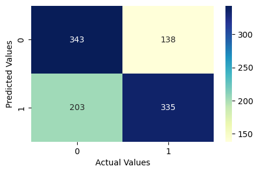

```python
print(" Test Accuracy score : ",round(lr.score(x_test,y_test)*100,2),"%")
print("Train Accuracy score : ",round(lr.score(x_train,y_train)*100,2),"%")
print("----------------------")
print("Classification Report")
print("----------------------")
con = confusion_matrix(lr_pred,y_test)
plt.figure(figsize=(5,3))
sns.heatmap(con, annot=True,cmap="YlGnBu",fmt='g')
plt.xlabel('Actual Values')
plt.ylabel('Predicted Values')
#print(classification_report(y_test,lr_pred))
con2 = classification_report(lr_pred,y_test)
print(f"CLASSIFICATION REPORT:\n{con2}")
```

# 6- Em relação à questão anterior, qual o modelo deveria ser escolhido para uma eventual operação. Responda essa questão mostrando a comparação de todos os modelos e justifique.

- SVM
- Árvores de Classificação
- Regressão Logística

Com base nos resultados obtidos, o algoritmo de SVM(suport vector machine) apresentou os melhores resultados na metricas de avaliação, com a Acuracy, precision e recall mais relevantes em coparação ao algoritmo de regressão Logística e arvore de classificação

## SVM

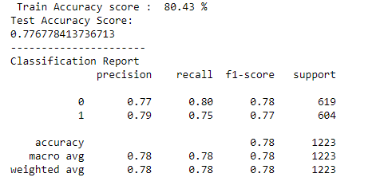

## Regressão Logistica

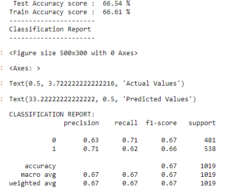

## Arvore de Classificação

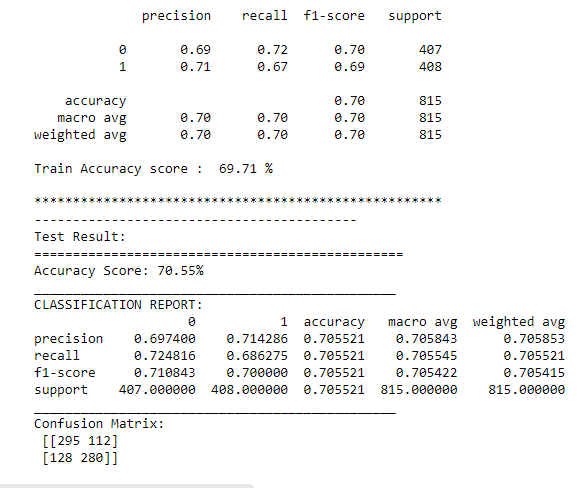